# network_analysis

Pietro Olivetti

2024-10-17

# Network analysis of Depression and Anxiety Symptomatology

## Packages and loading

```r
library(dplyr)
library(igraph)
library(qgraph)
library(bootnet)
library(corpcor)
library(openxlsx)
library(ggplot2)
library(tidyr)
library(matrixcalc)
library(e1071)
#library(smacof)
source('../data/questions.R')
```

```r
multiC <- function(cor_mat, t_hold = 0.8, name = ""){threshold <- t_hold
high_corr_pairs <- which(abs(cor_mat) > threshold & abs(cor_mat) < 1, arr.ind = TRUE)

# variable names and corresponding correlation values
high_corr_list <- data.frame(
  Variable1 = rownames(cor_mat)[high_corr_pairs[, 1]],
  Variable2 = colnames(cor_mat)[high_corr_pairs[, 2]],
  Correlation = cor_mat[high_corr_pairs]
)

# variables and their correlation values
df <- high_corr_list %>%
  arrange(desc(Correlation))}
```

## Organizing data

### All variables

Creating the dataframe and the group’s list for all variables

```r
# Dataframe
df <- read.csv('../data/data_cleaned_temp.csv')

# Groups
groups_all_variables <- list(Ids = 1, Sociodem = 2:8, Pers_BFI2 = 9:23, Pers_hexaco = 24:33, Depr_cesd = 34:53, Depr_phq = 54:62, Depr_promis = 63:90, Depr_qids = 91:106, Depr_Ans_dass = 107:120, Depr_Ans_hads = 121:134, Ans_gad = 135:141, Ans_tmas = 142:191, Ans_sas = 192:206)

########
```

### All Scales

Creating the dataframe and the group’s list for all scales

```r
# Dataframe
df_all_scales <- df[9:206]

groups_all_scales <- list(Pers_BFI2 = 1:15, Pers_hexaco = 16:25, Depr_cesd = 26:45, Depr_phq = 46:54, Depr_promis = 55:82, Depr_qids = 83:98, Depr_Ans_dass = 99:112, Depr_Ans_hads = 113:126, Ans_gad = 127:133, Ans_tmas = 134:183, Ans_sas = 184:198)

group_names <- c("Ids", "Sociodem", "Pers_BFI2", "Pers_hexaco", "Depr_cesd", "Depr_phq", "Depr_promis", "Depr_qids", "Depr_Ans_dass", "Depr_Ans_hads", "Ans_gad", "Ans_tmas", "Ans_sas")
#######
```

### Scales related to anxiety and depression

Creating the dataframe and the group’s list for all scales related to depression and anxiety

```r
# Dataframe
df_anx_dp <- df[34:206]

# Groups
groups_anx_dep <- list(D_cesd = 1:20, D_phq = 21:29, D_promis = 30:57, D_qids = 58:73, A_dass = 74:80 , D_dass = 81:87 , A_hads = 88:94, D_hads = 95:101, A_gad = 102:108, A_sas = 109:123, A_tmas = 124:173)
```

### Scales related to anxiety and depression without TMAS

```r
# Dataframe
df_anx_dp_adj <- df_anx_dp[1:123]


# Groups
groups_anx_dep_adj <- list(D_cesd = 1:20, D_phq = 21:29, D_promis = 30:57, D_qids = 58:73, A_dass = 74:80 , D_dass = 81:87 , A_hads = 88:94, D_hads = 95:101, A_gad = 102:108, A_sas = 109:123)

# To be more readable on Network Graphs here is a vector of shortenned names

readable_anx_dp <- c("c01", "c02", "c03", "c04", "c05", "c06", "c07", "c08", "c09", "c10", "c11", "c12", "c13", "c14", "c15", "c16", "c17", "c18", "c19", "c20",
"ph01", "ph02", "ph03", "ph04", "ph05", "ph06", "ph07", "ph08", "ph09",
"pr01", "pr02", "pr03", "pr04", "pr05", "pr06", "pr07", "pr08", "pr09", "pr10", "pr11", "pr12", "pr13", "pr14", "pr15", "pr16", "pr17", "pr18", "pr19", "pr20", "pr21", "pr22", "pr23", "pr24", "pr25", "pr26", "pr27", "pr28",
"q01", "q02", "q03", "q04", "q05", "q06", "q07", "q08", "q09", "q10", "q11", "q12", "q13", "q14", "q15", "q16",
"d02", "d04", "d07", "d09", "d15", "d19", "d20", "d03", "d05", "d10", "d13", "d16", "d17", "d21",
"h01", "h03", "h05", "h07", "h09", "h11", "h13", "h02", "h04", "h06", "h08", "h10", "h12", "h14",
"g01", "g02", "g03", "g04", "g05", "g06", "g07",
"s01", "s02", "s03", "s04", "s05", "s06", "s07", "s08", "s09", "s10", "s11", "s12", "s13", "s14", "s15")
#"t01", "t02", "t03", "t04", "t05", "t06", "t07", "t08", "t09", "t10", "t11", "t12", "t13", "t14", "t15", "t16", "t17", #"t18", "t19", "t20", "t21", "t22", "t23", "t24", "t25", "t26", "t27", "t28", "t29", "t30", "t31", "t32", "t33", "t34", #"t35", "t36", "t37", "t38", "t39", "t40", "t41", "t42", "t43", "t44", "t45", "t46", "t47", "t48", "t49", "t50")

# Group names
group_names_anx_dep <- c("Depr_cesd", "Depr_phq", "Depr_promis", "Depr_qids", "Ans_dass" , "Depr_dass" , "Ans_hads", "Depr_hads", "Ans_gad", "Ans_sas")
```

## Descriptive Statistics

### Demographics

```r
#to be done
```

### General Statistics about the scales

```r
#to be done
```

## Force-directed plotting with Fruchterman–Reingold

Most studies on networks in psychopathology have used the Fruchterman-Reingold (FR) algorithm to create graphs (Borsboom et al., 2021). This algorithm is like setting up a system of balls connected by stretchy strings. The strings pull connected balls closer, while the other balls push them apart, resulting in a graph where nodes are well-spaced and edges are evenly distributed (Deserno et al., 2022).

The goal of force-directed algorithms is not to place nodes in specific meaningful locations, but to make the network easy to view, showing connections and clusters clearly. The arrangement produced by these algorithms is primarily driven by the need for visual clarity and does not necessarily reflect any inherent structure or meaning beyond the connections themselves. Therefore, it is crucial to focus on the connections between nodes and their strengths, rather than the spatial arrangement of nodes, when interpreting a force-directed graph (Deserno et al., 2022).

The spatial positions of nodes in these graphs are highly sensitive to variations in edge weights, even those as small as 0.01. A slight alteration in edge weights can lead to significant changes in the node arrangement (Burger et al., 2022). Therefore, the layout should not be interpreted as reflecting inherent properties or relationships among the nodes beyond their connection.

### Testing different correlation methods

Spearman Correlation, as mentioned, is particularly useful for analyzing non-parametric data. Spearman correlations, or rank-based correlations, can be used to handle non-normal continuous or ordered categorical data. On the other hand, automatic recognition of data type with cor_auto function from qgraph typically creates a dense correlation matrix, incorporating automatic correction for ordinal and continuous data, which can lead to multicollinearity. ForcePD forces the matrix to be positive definite. A positive definite matrix guarantees that all its eigenvalues are positive, a condition crucial for methods like testing the robustness of the network. Multicollinearity arises when predictor variables in a model are highly correlated, making it challenging to discern the unique effect of each predictor (Epskamp, Borsboom, & Fried, 2018). Therefore, testing which adjencency matrix is better in terms of multicollinearity and knowing whether it is positive. The results below show that both matrices are positive definite but what actually indicates that Spearman is the most suitable method for our data is the amount of variable pairs over a threshold of 0.8. While Spearman hasarount 34 pairs with that extremelly high correlation, the cor_auto function has 1232 pairs.

```r
# cor_auto
symp_auto <- cor_auto(df_anx_dp_adj, forcePD = TRUE)

# Spearman Correlation

symp_spear <- cor(df_anx_dp_adj, method = "spearman")


mc_auto <- multiC(symp_auto)
head(mc_auto, 5)
```

```
##   Variable1 Variable2 Correlation
## 1   cesd_06   cesd_04   0.9393579
## 2   cesd_04   cesd_06   0.9393579
## 3   cesd_04   cesd_02   0.9321279
## 4   cesd_02   cesd_04   0.9321279
## 5 promis_12 promis_10   0.9253653
```

```r
cat("\nAutomatic correlation method is positive definite = ", is.positive.definite(symp_auto), "\nIts amount of variable pairs over the threshold of 0.8 is:", nrow(mc_auto))
```

```
##
## Automatic correlation method is positive definite =  TRUE
## Its amount of variable pairs over the threshold of 0.8 is: 1232
```

```r
mc_spear <- multiC(symp_spear)
head(mc_spear, 5)
```

```
##   Variable1 Variable2 Correlation
## 1 promis_12 promis_10   0.8486060
## 2 promis_10 promis_12   0.8486060
## 3 promis_05 promis_02   0.8340622
## 4 promis_02 promis_05   0.8340622
## 5   cesd_06   cesd_04   0.8288046
```

```r
cat("\nSpearman method is positive definite = ", is.positive.definite(symp_spear), "\nIts amount of variable pairs over the threshold of 0.8 is:", nrow(mc_spear))
```

```
##
## Spearman method is positive definite =  TRUE
## Its amount of variable pairs over the threshold of 0.8 is: 34
```

### Creating networks out of individual scales using FR algorithm and Spearman Correlation

The Spearman correlation is particularly useful for analyzing non-parametric data, such as those generated by Likert scales, which are commonly employed in psychological research. Likert scales typically consist of a set of statements or questions with ordered response categories, such as “strongly agree,” and “strongly disagree”. The ordered nature of these responses often violates the assumptions of parametric statistical methods that require continuous, normally distributed data (Blanken et al., 2022)*. Spearman correlation, as a non-parametric method, does not rely on these assumptions and can be used to assess the strength and direction of the association between variables measured on Likert scales. This makes it a valuable tool for examining relationships between variables that do not meet the criteria for parametric analyses, providing researchers with a robust alternative for analyzing data commonly encountered in psychological research.

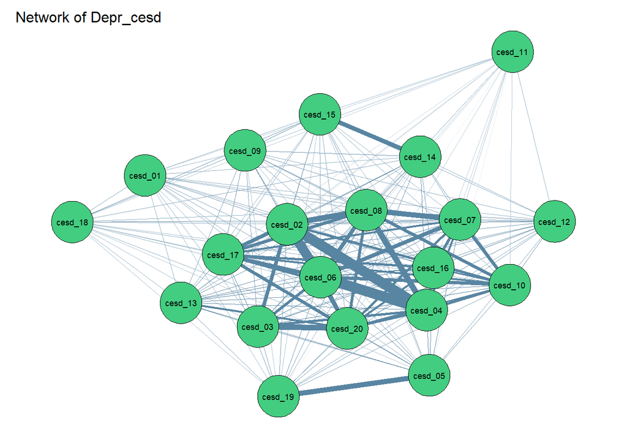

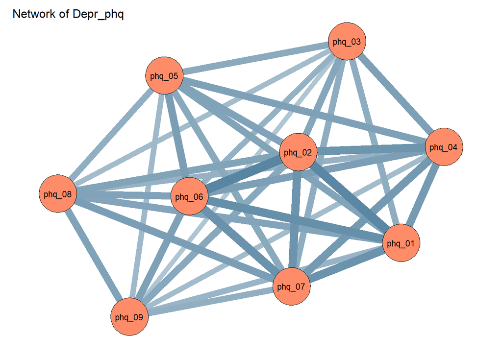

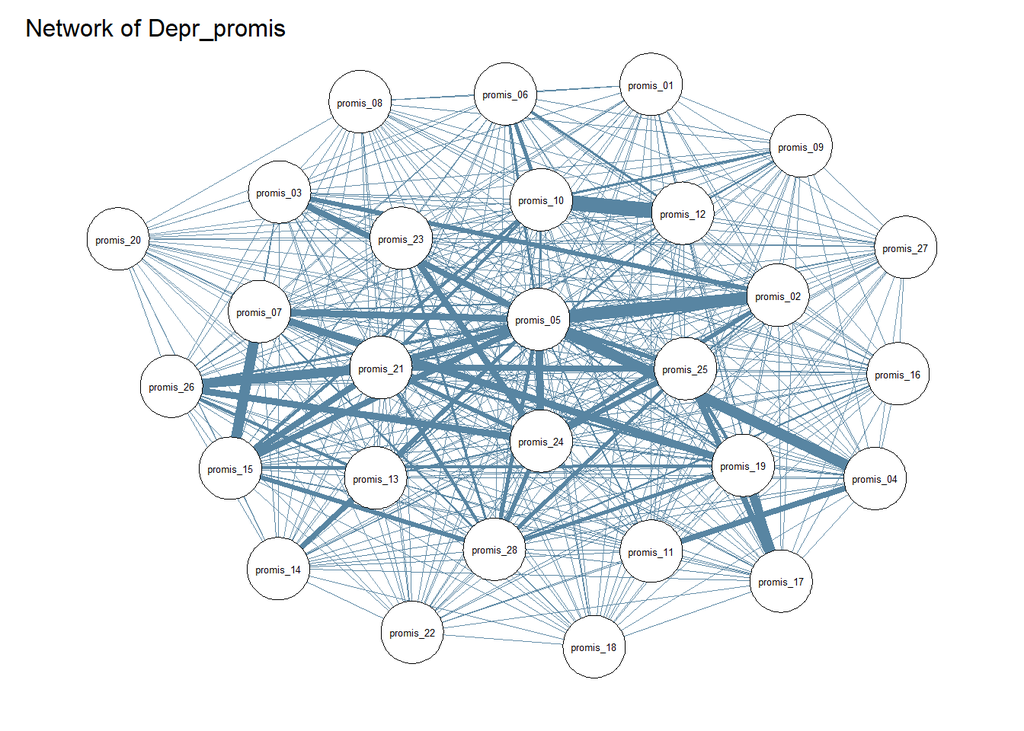

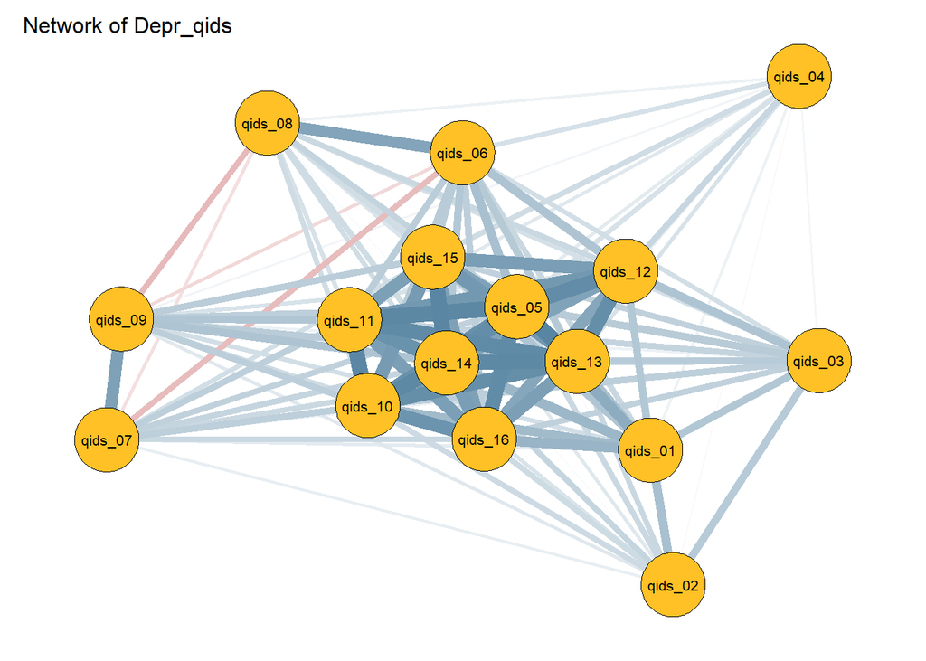

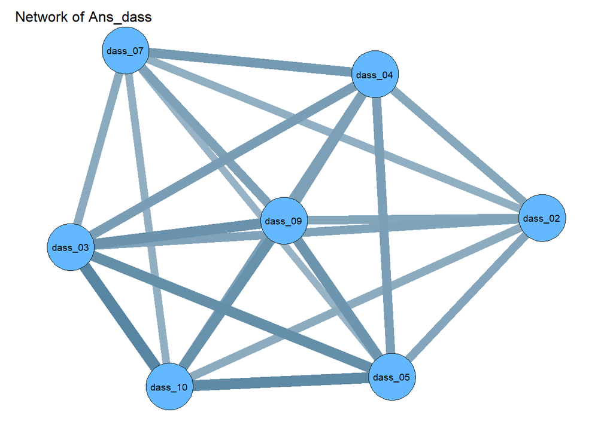

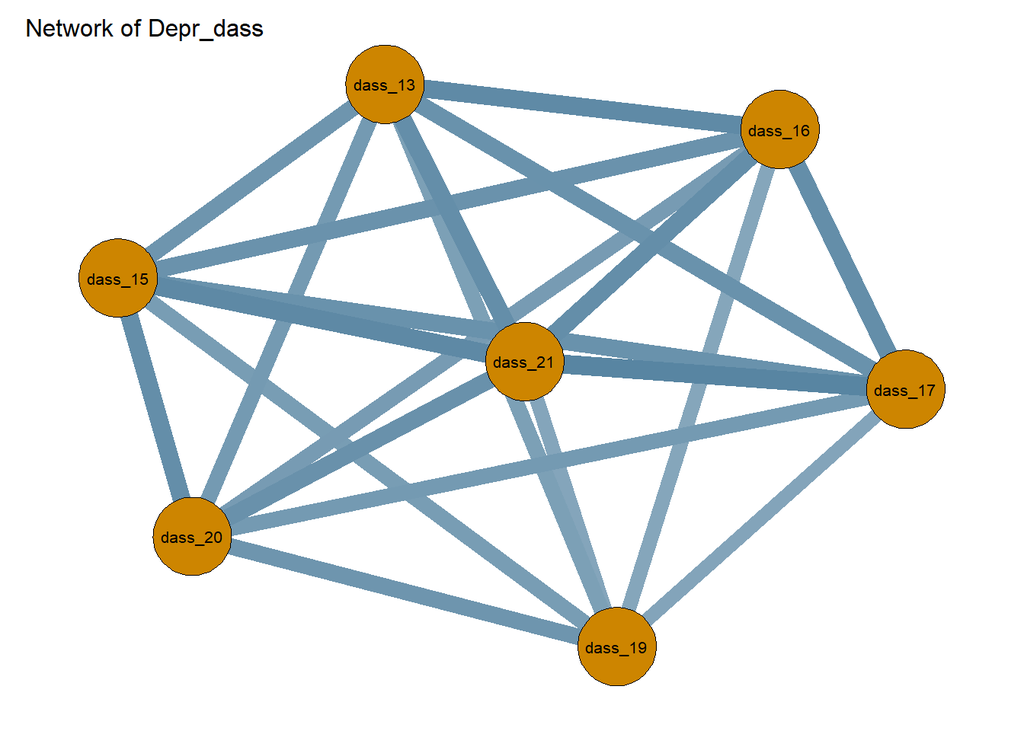

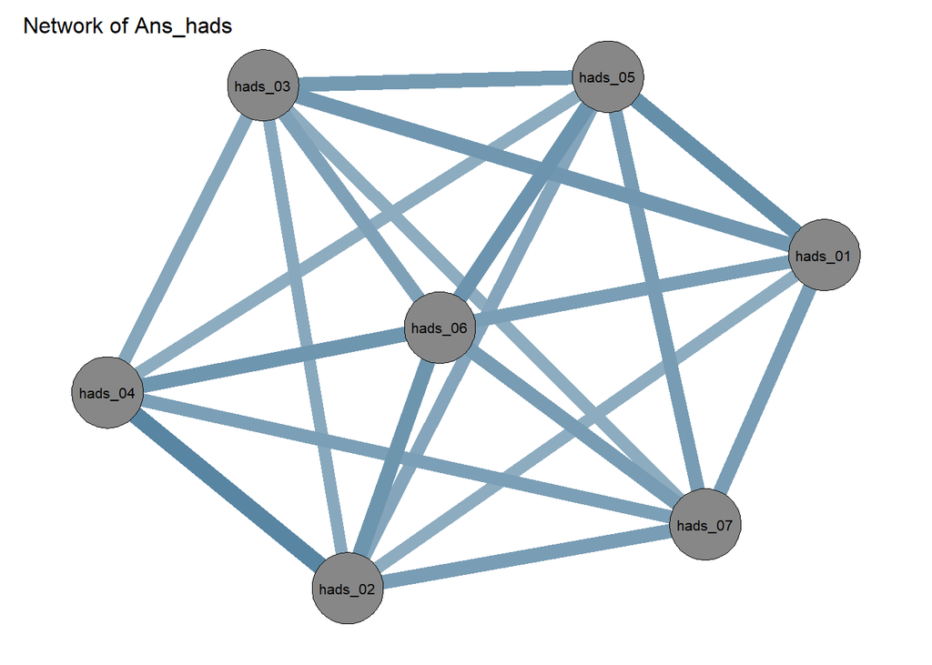

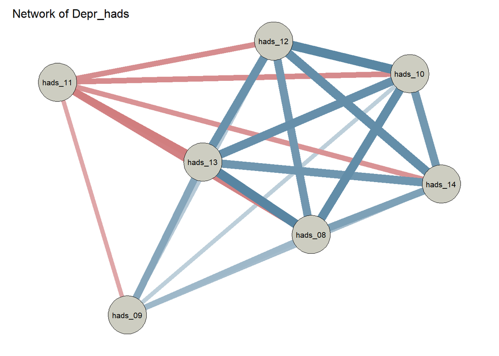

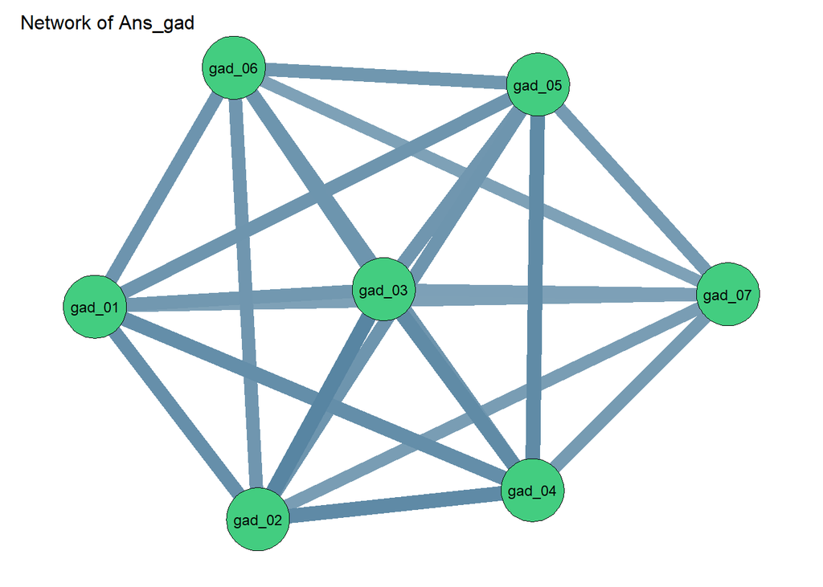

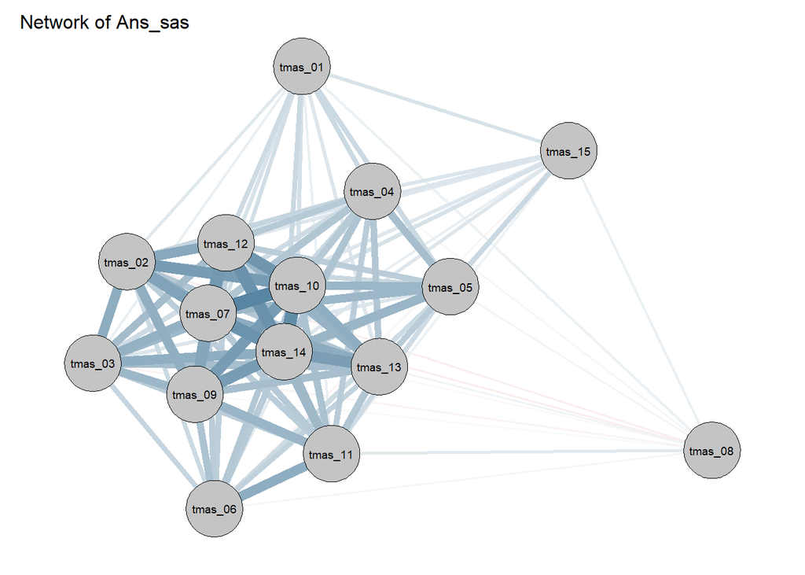

```r
n <- 1
for(sc in groups_anx_dep_adj){
  zero_order_scale <- cor(df_anx_dp_adj[sc], method = "spearman")
  qgraph(zero_order_scale, layout="spring", labels = colnames(zero_order_scale), color = sample(colors(), 1), theme="TeamFortress", height = 180, width = 140, title = paste("Network of", group_names_anx_dep[n]))

  n <- n + 1
}
```

## Network graphs

[figure not shown]

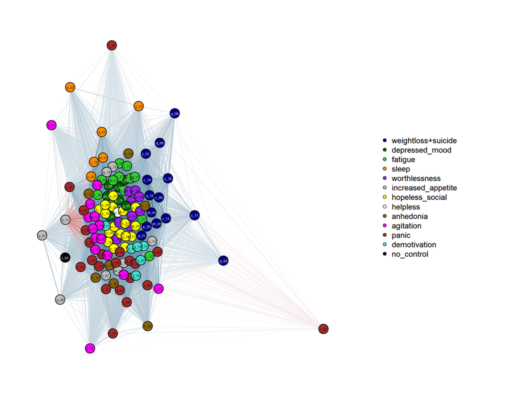

```r
symp_spear <- cor(df_anx_dp_adj, method = "spearman")

color_nodes_symp_df <- c("darkblue", "darkgreen", "limegreen", "darkorange", "purple", "grey", "yellow", "white", "darkgoldenrod4", "magenta", "brown", "turquoise", "black")

lsymp <- list('weightloss+suicide' = c(1, 9, 11, 14, 15, 18, 28, 29, 49, 61, 63, 65, 69, 87), 'depressed_mood' = c(2, 4, 6, 22, 36, 44, 62), 'fatigue' = c(3,   7,  8,  10, 12, 13, 16, 20, 21, 24, 27), 'sleep' = c(5, 19, 23, 58, 59, 60), 'worthlessness' = c(17,    26, 30, 35, 37, 38, 39, 41, 56), 'increased_appetite' = c(25,   64, 66, 67, 68, 71, 72, 98, 115), 'hopeless_social' = c(31, 33, 34, 40, 42, 43, 45, 46, 47, 48, 50, 51, 52, 53, 54, 55, 57), 'helpless' = c(32), 'anhedonia' = c(70,    95, 96, 97, 99, 100,    101), 'agitation' = c(73,   88, 90, 91, 93, 102,    103,    104,    105,    106,    107,    109,    111,    114), 'panic' = c(74,   75, 76, 77, 78, 79, 80, 89, 92, 94, 108,    110,    113,    116,    117,    118,    119,    120,    121,    122,    123), 'demotivation' = c(81,    82, 83, 84, 85, 86), 'no_control' = c(112))

qgraph(symp_spear, layout="spring", labels = colnames(readable_anx_dp),sampleSize = nrow(df_anx_dp_adj), groups = lsymp, color = color_nodes_symp_df, theme="TeamFortress", label.prop=0.8, vsize=2, label.cex=1)
```